# labortorio-1

adrian rodriguez- c16648

2023-01-20

# Introducción

El Programa Estado de la Nación ha logrado consolidar una base de datos sobre la legislación aprobada en Costa Rica entre los años 1986 y 2022. En esta base se trabaja sobre el tipo de legislación aprobada, y la duración que se toman las diputadas y los diputados para aprobar las leyes.

Se tienen las siguientes variables:

1. Ley: número de ley
2. Expediente: número de expediente
3. NombreLey: Nombre de la ley
4. OrganoAprobacion: órgano legislativo en donde fue aprobada la ley. Puede ser el plenario, referendo o alguna de las comisiones con capacidad pleba.
5. IniciativaPoder: Poder que presenta la ley. Puede ser el ejectuvo, el legislativo o por iniciativa popular
6. Legislatura: Periodo legislativo en que fue aprobado
7. Periodo: tipo de periodo legislativo. Puede ser ordinario o extraordinario
8. Duracion: duración en días entre la presentación del proyecto a la aprobación de este.
9. TipoLegislacion: tipo de legislación.

Utilizando esta base, realice lo siguiente:

1. Establezca la carpeta de trabajo

```r
setwd("C:/Users/Adrian/Desktop/adrian/UCR/cuarto semestre/CUANTI II")
library(readxl)
library(tidyr)
library(dplyr)
```

```r
library(ggplot2)
```

2. Cargue la base de datos

```r
baseleyes<- read_xlsx("legislacion.xlsx")
View(baseleyes)
```

3. Realice una tabla que resuma el porcentaje de leyes aprobadas por legislatura

```r
baseleyes %>%select(Legislatura) %>%
  group_by(Legislatura) %>%
  summarise(total=n()) %>%
  mutate(Porcentaje=total/sum(total)*100)
```

```
## # A tibble: 36 × 3
##    Legislatura total Porcentaje
##    <chr>       <int>      <dbl>
##  1 1986-1987      24      0.745
##  2 1987-1988      30      0.931
##  3 1988-1989      33      1.02
##  4 1989-1990      20      0.621
##  5 1990-1991      92      2.86
##  6 1991-1992      60      1.86
##  7 1992-1993      45      1.40
##  8 1993-1994      65      2.02
##  9 1994-1995     101      3.14
## 10 1995-1996      95      2.95
## # … with 26 more rows
```

4. Calcule e interprete cada una de los siguientes descriptivos :

```r
promedio<-mean(baseleyes$DuracionDias, na.rm=T)
promedio
```

```
## [1] 654.738
```

# La media aritmetica es de 654.7 que es el valor promedio en el resumen de los datos

```r
meadiana<-median(baseleyes$DuracionDias, na.rm=T)
meadiana
```

```
## [1] 502
```

# Es el punto medio de los datos, el percentil 50%, la mitad de los datos se encuentra por encima de 502 y la otra mitad por debajo

```r
desviacionestandar<- sd(baseleyes$DuracionDias, na.rm=T)
desviacionestandar
```

```
## [1] 630.5888
```

# En promedio, los datos se alejan de la media en 630.5888 dias

5. Realice el **boxplot**, e interprételo

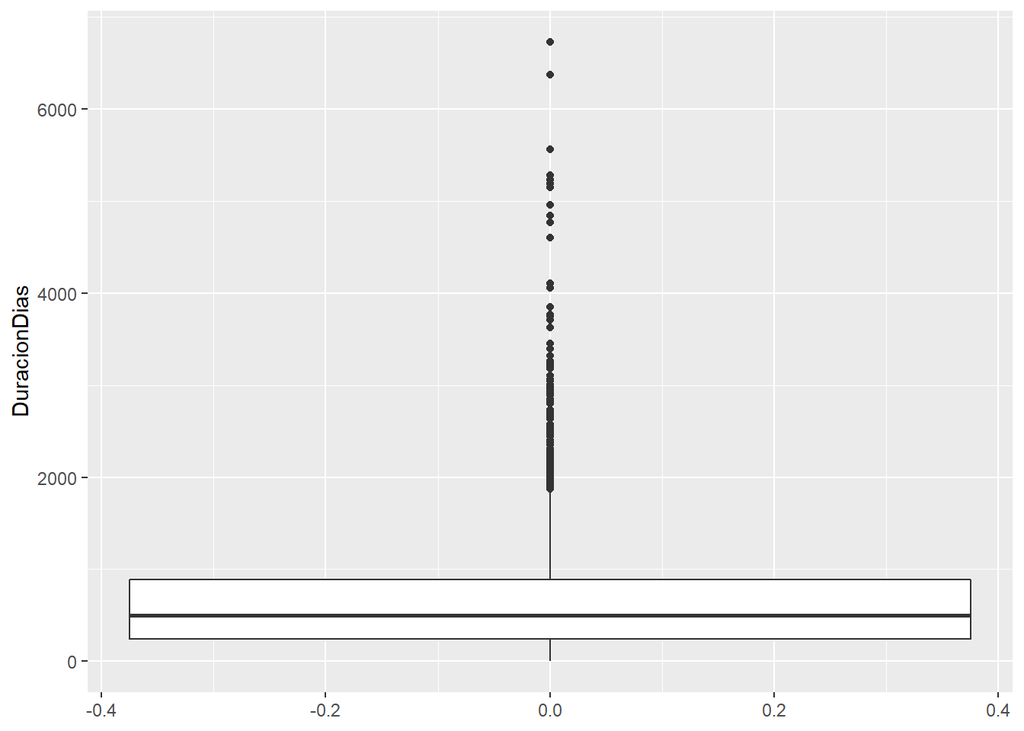

```r
baseleyes%>%ggplot(aes(y=DuracionDias))+
  geom_boxplot()
```

# Al tener valores extremos se decide que lo mejor es interpretar el plot con la mediana que 502 dias por lo cual el 50% de los datos estan por encima de esta y el otro 50% esta por debajo de esta

6. Genere una tabla en donde se muestre el promedio de duración de las leyes, según la legislatura aprobada.

```r
baseleyes %>% select(Legislatura, DuracionDias)%>% group_by(Legislatura) %>% summarise(promedio=mean(DuracionDias, na.rm=T))
```

```
## # A tibble: 36 × 2
##    Legislatura promedio
##    <chr>          <dbl>
##  1 1986-1987       489.
##  2 1987-1988      1103.
##  3 1988-1989       660.
##  4 1989-1990       810.
##  5 1990-1991       804.
##  6 1991-1992       588.
##  7 1992-1993       664.
##  8 1993-1994       892.
##  9 1994-1995       740.
## 10 1995-1996       649.
## # … with 26 more rows
```

7. Cree un gráfico que presente la información mostrada en la tabla anterior.

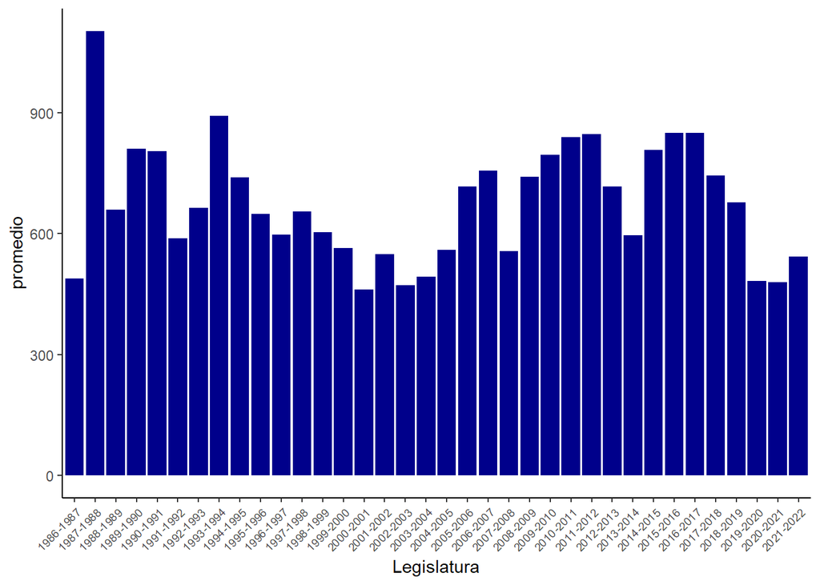

```r
baseleyes %>% select(Legislatura, DuracionDias)%>% group_by(Legislatura) %>% summarise(promedio=mean(DuracionDias, na.rm=T)) %>% ggplot(aes(x=Legislatura, y=promedio))+
  geom_col(aes(y = promedio), fill="darkblue")+
  theme_classic()+
  theme(axis.text.x=element_text(angle=45, hjust =1, size = 7))
```

8. Obtenga una muestra de 800 leyes de la base de datos total

```r
set.seed(48)
```

```r
N= 3221
n= 800
aleatorio<-sample(1: N,n)
head(aleatorio)
```

```
## [1] 1093 2218  179  153 2853 2511
```

9. Calcule el promedio de duración de las leyes de la muestra y compárelo con el valor de la población ¿Cuanto es la diferencia?

```r
muestra <- baseleyes[aleatorio,]
mean(muestra$DuracionDias)
```

```
## [1] 643.9937
```

```r
diferencia<-654.738-643.9937
diferencia
```

```
## [1] 10.7443
```

# EL promedio de la poblacion es 654.738 dias mientras que el promedio de la muestra 643.9937 dias por lo que se encuentra una diferencia de 10.7443

10. Obtenga el intervalo de confianza e interprételo.

```r
t.test(muestra$DuracionDias)
```

```
##
##  One Sample t-test
##
## data:  muestra$DuracionDias
## t = 29.85, df = 799, p-value < 2.2e-16
## alternative hypothesis: true mean is not equal to 0
## 95 percent confidence interval:
##  601.6449 686.3426
## sample estimates:
## mean of x
##  643.9937
```

# Con un 95% de confianza se puede decir que el intervalo de confianza contiene el valor del parametro

11 ¿Es una buena muestra la obtenida? Justifique

# Debido a que el promedio de la muestra se encuentra entre 601.6449 y 686.3426 se puede determinar que es una buena muestra